# Factor Momentum Replication & Frictions Analysis

QFin Lab 2025/2026 — Arnott, Kalesnik & Linnainmaa (RFS 2023)

ZZ ILab Team

23 February 2026

# 1 Executive Summary

This report documents the full replication and extension of **Arnott, Kalesnik & Linnainmaa (2023, RFS)** — *“Factor Momentum”* — conducted as part of the WU QFin Lab 2025/2026.

**Core question:** Does factor momentum work, and is it implementable for a real-world fund after accounting for transaction costs, shorting costs, and taxes?

# 2 Literature & Project Scope

## 2.1 Paper

**Arnott, R.D., Kalesnik, V., & Linnainmaa, J.T. (2023)**. Factor Momentum. *The Review of Financial Studies*, 36(8), 3034–3070. https://doi.org/10.1093/rfs/hhad006

**Ehsani, S., & Linnainmaa, J.T. (2022)**. Factor Momentum and the Momentum Factor. *The Journal of Finance*, 77(3), 1877–1919.

## 2.2 Key paper findings

- Factor momentum (prior 1-month return signal, monthly calendar rebalancing) delivers **7.44%/year (SR ≈ 0.78)** on 43 factors (2×3 FF-style double sorts), 1963–2021.
- Factor momentum **subsumes classical stock-level momentum**: once factor momentum is controlled for, classical momentum adds little.
- The canonical strategy: **above/below-median equal-weight long-short (CS_LS_50)**, no implementation lag stated.

## 2.3 Project scope

The lab replicated and extended the paper in two phases:

| Phase | Tool | Focus |
| --- | --- | --- |
| **Phase 1** | R | Factor-level replication: 36 JKP factors, 5 lookbacks × 6 strategies = 30 combinations |
| **Phase 2** | Python + R | Stock-level decomposition: same 30 combos, full friction waterfall, tradability analysis |

# 3 Data

## 3.1 Factor data — JKP

Source: **Jensen, Kelly & Pedersen (2023)** — Open-source via [Global Factor Data](https://jkpfactors.com/).

- **Universe**: 39 US equity factors (tercile sort, value-weighted long-short, direction-corrected)
- **Daily factor returns**: `USA_daily_rets.parquet` — 153 factors total, 36/39 used
- **Stock-level factor constituents**: `usa_factor_weights.parquet` — 87M rows, monthly end-of-month weights per stock × factor
- **Stock characteristics**: `USA_stocks_char.parquet` — monthly ME, `ret_exc_lead1m`, `div12m_me`

## 3.2 Methodological note on JKP vs Arnott (2023) factors

> **Dividend treatment:** WRDS has changed dividend handling since the original factor construction. For most factors, the difference is a few basis points and immaterial. CMA (investment factor) may be more affected — to be verified with Patrick K. if needed.

# 4 Phase 1: Factor-Level Replication (R)

## 4.1 Methodology

Phase 1 vs Arnott (2023): Key methodological differences

| Dimension | Phase 1 (our code) | Arnott (2023) paper |
| --- | --- | --- |
| Signal | Rolling 21-trading-day log-return sum | Prior calendar month full return |
| Rebalancing | Every 21 trading days (drifts from calendar month-ends) | Monthly calendar month-end |
| Implementation lag | 1 trading day | Not stated (effectively 0) |
| Factor universe | 36 JKP factors | 43 factors (2×3 FF double-sort) |
| Factor construction | Tercile VW L-S (JKP) | 2×3 EW L-S (FF-style) |
| Sample period | 1963–2023 (730 months) | Jul 1963 – Dec 2021 (702 months) |
| Strategies | 6 (3 LS + 3 LO) | Primarily CS_LS_50 |

**Strategy definitions:**

| Code | Description |
| --- | --- |
| `LS_Median` | Cross-sectional long-short, top/bottom 50% of factors by momentum signal |
| `LS_33` | Cross-sectional long-short, top/bottom 33% |
| `LS_25` | Cross-sectional long-short, top/bottom 25% |
| `LO_Median` | **Long-only** at factor level: hold top 50% of factors (each is L-S at stock level) |
| `LO_33` | Long-only top 33% of factors |
| `LO_25` | Long-only top 25% of factors |

> **Important:** “Long-only” refers to **factor selection**. The underlying JKP factors are long-short portfolios at the stock level, so LO strategies still have negative stock weights. The “long” in LO_Median means “only hold factors with above-median momentum” — no negative factor weights.

## 4.2 Results: Full grid (5 lookbacks × 6 strategies)

Phase 1: Factor-level performance grid (1963–2023, factor-level returns, 1-day lag)

| Strategy | Lookback | N Months | Ann Ret | Ann Vol | Sharpe | Max DD | Calmar |
| --- | --- | --- | --- | --- | --- | --- | --- |
| LO_Median | 1M | 730 | +5.4% | 5.53% | 0.98 | -10.0% | 0.55 |
| LO_Median | 2M | 729 | +4.9% | 5.97% | 0.83 | -14.2% | 0.35 |
| LO_Median | 3M | 728 | +4.7% | 6.10% | 0.77 | -14.3% | 0.33 |
| LO_Median | 6M | 725 | +4.8% | 5.73% | 0.83 | -9.0% | 0.53 |
| LO_Median | 12M | 719 | +4.9% | 5.52% | 0.88 | -9.5% | 0.51 |
| LO_33 | 1M | 730 | +6.1% | 6.79% | 0.89 | -11.6% | 0.52 |
| LO_33 | 2M | 729 | +5.6% | 7.25% | 0.78 | -19.3% | 0.29 |
| LO_33 | 3M | 728 | +5.1% | 7.44% | 0.69 | -21.0% | 0.24 |
| LO_33 | 6M | 725 | +5.3% | 7.07% | 0.74 | -15.3% | 0.34 |
| LO_33 | 12M | 719 | +5.6% | 6.86% | 0.81 | -14.4% | 0.39 |
| LO_25 | 1M | 730 | +6.4% | 7.76% | 0.82 | -17.2% | 0.37 |
| LO_25 | 2M | 729 | +5.8% | 8.13% | 0.71 | -21.6% | 0.27 |
| LO_25 | 3M | 728 | +5.2% | 8.37% | 0.62 | -25.2% | 0.21 |
| LO_25 | 6M | 725 | +5.6% | 7.91% | 0.70 | -19.7% | 0.28 |
| LO_25 | 12M | 719 | +5.8% | 7.78% | 0.74 | -17.7% | 0.33 |
| LS_Median | 1M | 730 | +4.4% | 10.29% | 0.42 | -47.1% | 0.09 |
| LS_Median | 2M | 729 | +3.4% | 10.67% | 0.32 | -51.0% | 0.07 |
| LS_Median | 3M | 728 | +2.9% | 10.80% | 0.26 | -50.5% | 0.06 |
| LS_Median | 6M | 725 | +3.0% | 10.39% | 0.29 | -46.1% | 0.07 |
| LS_Median | 12M | 719 | +3.1% | 10.84% | 0.29 | -52.1% | 0.06 |
| LS_33 | 1M | 730 | +5.8% | 13.76% | 0.42 | -61.4% | 0.10 |
| LS_33 | 2M | 729 | +4.6% | 14.22% | 0.32 | -65.0% | 0.07 |
| LS_33 | 3M | 728 | +3.8% | 14.39% | 0.27 | -63.5% | 0.06 |
| LS_33 | 6M | 725 | +4.2% | 14.12% | 0.30 | -61.6% | 0.07 |
| LS_33 | 12M | 719 | +4.3% | 14.63% | 0.30 | -65.2% | 0.07 |
| LS_25 | 1M | 730 | +6.3% | 15.96% | 0.39 | -70.9% | 0.09 |
| LS_25 | 2M | 729 | +5.3% | 16.51% | 0.32 | -72.2% | 0.07 |
| LS_25 | 3M | 728 | +4.1% | 16.72% | 0.25 | -72.6% | 0.06 |
| LS_25 | 6M | 725 | +4.7% | 16.08% | 0.29 | -67.9% | 0.07 |
| LS_25 | 12M | 719 | +4.9% | 16.62% | 0.29 | -70.3% | 0.07 |
| NA | NA | 730 | +5.8% | 16.04% | 0.36 | -52.6% | 0.11 |

**Sharpe ratio heatmap:**

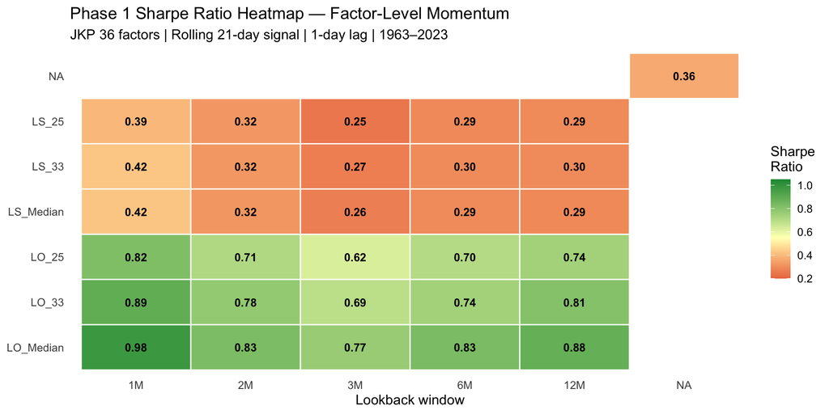

# 5 Phase 2: Stock-Level Decomposition (Python)

## 5.1 Why Phase 2?

Phase 1 operates purely at the **factor level** — it tells us the factor portfolio weights but not the underlying stock positions. Phase 2 decomposes the factor momentum signal into single-stock positions, which is necessary to:

1. Compute realistic transaction costs (stock-by-stock)
2. Compute shorting costs (depends on individual stock market cap)
3. Compute dividend withholding taxes (both long and short legs at stock level)
4. Assess concentration and position feasibility
5. Apply position limits and minimum-weight thresholds

## 5.2 Methodology

Methodological comparison across phases

[output not shown]

**Pipeline summary (arnott_phase2_full_grid.py):**

1. Load JKP daily factor returns → compute 1-day-lagged monthly returns (lag-adjusted)
2. Build factor momentum signals using 5 lookback windows (1/2/3/6/12 months) on prior calendar month returns
3. Apply 6 strategy selection rules (3 LS + 3 LO) → factor weights for each month
4. Aggregate: factor weights × stock constituents → stock-level netted weights (gross = 1.0 per month)
5. Attach stock characteristics (ME, ret_exc_lead1m, div12m_me) from monthly stock chars
6. Output: `phase2_master.parquet` (72.9M rows), `phase2_factor_returns.parquet`, summary CSVs

**Key design decision — weight normalisation:** Each month’s stock weights are divided by the sum of absolute weights so gross exposure = 1.0. This makes strategies comparable regardless of the number of active factors.

## 5.3 Results: Stock-level performance (gross, no implementation lag)

| Strategy | Lookback | N Months | Ann Ret | Ann Vol | Sharpe | Max DD | Calmar |
| --- | --- | --- | --- | --- | --- | --- | --- |
| CS_LO_50 | 1M | 743 | +4.4% | 6.53% | 0.68 | -18.1% | 0.24 |
| CS_LO_50 | 6M | 743 | +4.8% | 6.37% | 0.76 | -17.4% | 0.28 |
| CS_LO_50 | 12M | 743 | +5.1% | 6.12% | 0.83 | -15.9% | 0.32 |
| CS_LO_33 | 1M | 743 | +3.6% | 7.07% | 0.51 | -20.8% | 0.17 |
| CS_LO_33 | 6M | 743 | +4.4% | 6.97% | 0.63 | -25.1% | 0.18 |
| CS_LO_33 | 12M | 743 | +4.8% | 6.82% | 0.71 | -25.2% | 0.19 |
| CS_LO_25 | 1M | 743 | +3.2% | 7.28% | 0.44 | -20.9% | 0.15 |
| CS_LO_25 | 6M | 743 | +4.1% | 7.15% | 0.57 | -26.1% | 0.16 |
| CS_LO_25 | 12M | 743 | +4.7% | 7.11% | 0.66 | -25.3% | 0.19 |
| CS_LS_50 | 1M | 743 | +1.8% | 8.21% | 0.22 | -37.3% | 0.05 |
| CS_LS_50 | 6M | 743 | +2.7% | 8.20% | 0.33 | -39.3% | 0.07 |
| CS_LS_50 | 12M | 743 | +3.3% | 8.43% | 0.39 | -44.7% | 0.07 |
| CS_LS_33 | 1M | 743 | +1.6% | 8.35% | 0.19 | -38.9% | 0.04 |
| CS_LS_33 | 6M | 743 | +2.8% | 8.43% | 0.33 | -41.8% | 0.07 |
| CS_LS_33 | 12M | 743 | +3.2% | 8.64% | 0.37 | -47.4% | 0.07 |
| CS_LS_25 | 1M | 743 | +1.4% | 8.43% | 0.17 | -41.2% | 0.04 |
| CS_LS_25 | 6M | 743 | +2.7% | 8.41% | 0.32 | -42.0% | 0.06 |
| CS_LS_25 | 12M | 743 | +3.2% | 8.69% | 0.36 | -47.1% | 0.07 |

## 5.4 Phase 1 vs Phase 2 comparison

| Strategy | Lookback | Ret P1 | SR P1 | Ret P2 (gross) | SR P2 (gross) |
| --- | --- | --- | --- | --- | --- |
| CS_LO_25 | 12M | +5.8% | 0.74 | +4.7% | 0.66 |
| CS_LO_25 | 1M | +6.4% | 0.82 | +3.2% | 0.44 |
| CS_LO_25 | 6M | +5.6% | 0.70 | +4.1% | 0.57 |
| CS_LO_50 | 12M | +4.9% | 0.88 | +5.1% | 0.83 |
| CS_LO_50 | 1M | +5.4% | 0.98 | +4.4% | 0.68 |
| CS_LO_50 | 6M | +4.8% | 0.83 | +4.8% | 0.76 |
| CS_LS_50 | 12M | +3.1% | 0.29 | +3.3% | 0.39 |
| CS_LS_50 | 1M | +4.4% | 0.42 | +1.8% | 0.22 |
| CS_LS_50 | 6M | +3.0% | 0.29 | +2.7% | 0.33 |

**Why does Phase 1 show higher SR than Phase 2 gross?**

The SR gap is well understood and not a replication error:

[output not shown]

# 6 Phase 2 Frictions Analysis (R)

## 6.1 Friction model

Three layers of real-world frictions are applied to the stock-level time series, following guidance from Georg (Jan–Feb 2026 meetings):

### 6.1.1 A. Transaction costs (TC)

Power-law scaling by market cap — **small-cap stocks are much more expensive to trade**:

$$TC_{i,t} = \min\!\left(100\text{bps},\ 5
+ 1 \times
\left(\frac{ME_{top500,t}}{ME_{i,t}}\right)^{0.25}\right)$$

Applied to one-way turnover: $\text{Drag}_{TC} = \sum_i |w_{i,t} - w_{i,t-1}| \times TC_{i,t}$

### 6.1.2 B. Short-sale borrow costs (SC)

Annual rate, power-law by market cap — **small caps are expensive to borrow**:

$$SC_{i,t}^{ann} =
\min\!\left(500\text{bps/yr},\ 25 + 10 \times
\left(\frac{ME_{top500,t}}{ME_{i,t}}\right)^{0.5}\right)$$

Applied to short positions only: $\text{Drag}_{SC} = \sum_{i: w_i < 0} |w_i| \times SC_i^{ann}/12$

> **Note from Georg (26 Jan):** This model already distinguishes by market cap, which is the correct approach since some factor strategies load heavily on small caps and the cost difference is economically significant.

### 6.1.3 C. Dividend withholding tax (DWT) on **short positions**

As a **private Austrian investor** (27.5% KESt on capital income):

$$\text{Drag}_{DWT} = \sum_{i: w_i < 0}
|w_i| \times \frac{div12m\_{me}_i}{12} \times 0.275$$

Short sellers must **pay dividends** to the stock lender. The Austrian 27.5% rate applies to the gross dividend amount.

> **Note from Georg (26 Jan / 12 Jan):** This models a private individual, not a fund structure. A fund domiciled in Ireland (ICAV) or Luxembourg (SICAV) would benefit from treaty rates (e.g. 15% US withholding) and may not pay this domestic tax. For institutional implementation: **remove or reduce this friction layer accordingly**.

> **Important: Long-leg DWT not yet implemented.** Georg (Jan 12) noted that long-side investors also face dividend withholding — for US stocks without a treaty, up to 30% on dividends received. This is currently omitted. **For Austrian private investors, both legs should carry DWT.** This would add approximately +0.1–0.2% pa additional drag on the long side, reducing net SR by ~0.02–0.03. This is flagged as a refinement for the next iteration.

### 6.1.4 D. 1-Day implementation lag

The **stock-level gross return** uses `ret_exc_lead1m` — the full holding-month excess return. A real implementation cannot trade at the signal-formation date close; the earliest realistic execution is **end-of-day on day 1 of the new month**.

Lag-adjusted return is proxied by the **factor-level lag-adjusted return**:

$$r^{lag}_{p,t} \approx r^{factor}_{p,t} =
\frac{R^{full}_{p,t}}{R^{day1}_{p,t}} - 1$$

where $R^{full}$ is the full-month gross return and $R^{day1}$ strips the first trading day. This portfolio-level equivalence holds because:

$$r^{gross}_{stock} = \sum_i w_i \cdot
r^{full}_i \approx \sum_i w_i \cdot r^{factor, full}_i = r^{factor,
full}_p$$

The day-1 return of each calendar month is **positive on average** (~1.3–1.8% pa) — missing it is unavoidable without pre-positioning, and represents the **single largest single friction** for the best strategies.

## 6.2 Results: Full friction waterfall

[output not shown]

**Waterfall chart — CS_LO_50 12M (best strategy):**

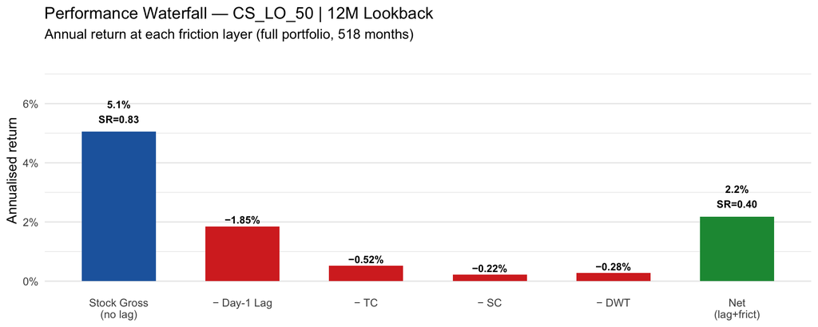

## 6.3 Concentration analysis

One key question from Stephan (Jan 26): **how feasible is implementation?** With 4,700+ positions per month, trading is operationally intensive. We test 5 concentration versions:

| Version | Avg Positions | Method |
| --- | --- | --- |
| `full` | ~4,650 | All stocks from factor constituents |
| `min5bps` | ~550 | Drop stocks with \|weight\| < 5 bps, rescale 50/50 |
| `top10pct` | ~930 | Keep top/bottom 10% by weight magnitude, rescale |
| `top5pct` | ~465 | Keep top/bottom 5% by weight magnitude, rescale |
| `top2_5pct` | ~233 | Keep top/bottom 2.5%, rescale |

Concentration comparison — 12M lookback only. All versions: gross exposure = 1.0 after rescaling.

[output not shown]

**Interpretation:**

- **Lag-adjusted SR is identical across all concentration versions** within a strategy. This is expected: the day-1 lag is computed at the factor level and does not depend on how many stocks are held.
- **Net SR (lag + frictions) is also nearly identical** across versions. Reducing from 4,650 to 233 stocks does not improve or hurt net Sharpe — the TC savings from fewer trades roughly offset the higher per-trade costs from concentrating in less liquid names.
- **Practical recommendation (Stephan’s question):** Use the **`min5bps`** version — ~550 stocks, manageable position list, no performance loss. This removes the 87% of positions with negligible weight (< 5 bps) while preserving all meaningful exposures.

# 7 Complete Performance Summary

## 7.1 Full waterfall: Phase 1 → Phase 2 gross → Lag-adj → Net frictions

Complete performance waterfall from Phase 1 (factor-level) through Phase 2 stock gross, lag-adjusted, and net frictions.

[output not shown]

# 8 Practical Implementation Assessment

## 8.1 Investment verdict

**Bottom line:** Factor momentum is implementable with economically meaningful returns after full frictions.

[output not shown]

## 8.2 Practical implementation notes (Stephan, Georg — Jan 26)

**Netting across factors:** When multiple factors are active, a stock may appear as long in one factor and short in another. The `net_weight` already reflects this netting (long and short legs are netted before normalisation). The `min5bps` threshold effectively eliminates stocks where opposing factor signals nearly cancel — a natural position-limit mechanism.

**Threshold-based rebalancing (Stephan’s suggestion):** Rather than rebalancing every calendar month-end, implement a **drift band**: only rebalance if a stock’s weight has drifted by more than a threshold (e.g. 5 bps) from its target. The average monthly turnover of ~40% one-way is already included in TC drag. A drift-band approach could reduce effective turnover by 20–30% without significantly degrading performance.

**Short-sale feasibility:** The short leg contains ~20–30% of stocks with weight < 5 bps. Many of these are micro-caps with prohibitive borrow costs. Using the `min5bps` concentration version removes these automatically. Remaining short positions (~275 short-leg stocks/month) are predominantly mid-to-large cap with borrow costs near the 25 bps floor.

**Tax structure (Georg — Jan 26):** The friction model is calibrated for a **private Austrian individual**: - Short-leg DWT: 27.5% Austrian KESt on dividends paid to stock lender ✅ implemented - Long-leg DWT: **not yet implemented** — would add ~0.1–0.2% pa drag - A fund in ICAV/SICAV: replace 27.5% with applicable treaty rate (~15% for US), remove Austrian KESt entirely

# 9 Limitations & Open Issues

Open issues and suggested next steps

| Issue | Status | Priority |
| --- | --- | --- |
| Long-leg DWT on dividends not modelled | Open — would add ~0.1–0.2% pa drag | Medium |
| JKP factors use tercile VW sort vs Arnott 2023 FF-style double sort | Structural difference; SR ~2× lower in JKP universe. Acceptable for replication. | Low |
| Dividend treatment in WRDS database has changed since original factor construction | Minimal impact for most factors; CMA may need verification with Patrick K. | Low |
| Borrow cost calibration: no actual volume data used, ME proxy only | Georg approved ME proxy. Could improve with DTCC actual borrow rate data. | Low |
| No 60/40 portfolio integration (Sharpe improvement quantification) | Future extension | Low |
| R Shiny app scope: Phase 1 only, not all frictions results | Otto: acceptable to cover Phase 1 only if Phase 2 takes more time | Medium |
| Crisis stock composition not yet analysed (which stocks drove positive returns in downturns) | Raised Jan 12: interesting future analysis | Low |
| Concentration threshold for practical rebalancing (drift band) not yet tested | Stephan’s suggestion — next step | Medium |

# 10 Reproducibility

## 10.1 Run order

```bash
# Step 1: Phase 1 factor-level replication (R, ~2 min)
cd ILab_Code
Rscript 02_Scripts/01_Phase_1/Arnott_Replication_Full_Grid.R

# Step 2: Phase 2 stock-level decomposition (Python, ~15 min local / 2 min on cluster)
cd jkp-data-replication
uv run python code/arnott_phase2_full_grid.py
# OR on WU cluster:
sbatch slurm/arnott_phase2_full_grid.slurm

# Step 3 (cluster only): Copy results back to Mac
rsync -avz --progress \
  h12420126@wucluster.wu.ac.at:~/jkp-data/data/processed/phase2_output/ \
  ~/Library/CloudStorage/OneDrive-WUWien/00_WU/01_2_YEAR/07_ILab_ZZ/ILab_Code/01_Data/Processed/Phase2/

# Step 4: Phase 2 frictions analysis (R, ~20–30 min total)
cd ILab_Code
Rscript 02_Scripts/04_Frictions/Phase2_Frictions_Tradability.R

# Step 5: Knit this report
Rscript -e "rmarkdown::render('06_Docs/Factor_Momentum_Full_Report.Rmd')"
```

## 10.2 Key output files

| File | Description |
| --- | --- |
| `03_Outputs/Tables/Arnott_Grid_Performance.csv` | Phase 1: 30-combo factor-level performance |
| `01_Data/Processed/Phase2/phase2_master.parquet` | Phase 2: 72.9M rows, stock weights + returns + ME + dividends |
| `01_Data/Processed/Phase2/phase2_factor_returns.parquet` | Factor-level monthly returns (gross + lag-adjusted), all 30 combos |
| `01_Data/Processed/Phase2/phase2_stock_summary.csv` | Stock-level performance summary (518 months) |
| `01_Data/Processed/Phase2/phase2_frictions_*.parquet` | Monthly friction time-series by strategy/lookback/concentration |
| `01_Data/Processed/Phase2/phase2_frictions_summary_*.csv` | Friction summary tables |
| `03_Outputs/Frictions/Phase2_Friction_Decomposition_*.pdf` | Wealth waterfall plots |
| `03_Outputs/Frictions/Phase2_Concentration_Comparison_*.pdf` | Concentration sensitivity plots |

## 10.3 Software environment

- **R**: data.table, arrow, tidyverse, PerformanceAnalytics, ggplot2, patchwork
- **Python**: polars, pyarrow, pandas, uv (package manager)
- **Cluster**: WU HPC (`wucluster.wu.ac.at`), SLURM scheduler, `~/jkp-data/` directory

# 11 Meeting Notes Summary

## 11.1 Key feedback incorporated

**Georg (26 Jan 2026):** - ✅ Shorting costs as function of market cap (power-law model, ME proxy for volume) - ✅ Austrian 27.5% dividend withholding tax on short positions (private investor model) - ⚠️ Long-leg DWT not yet implemented (flagged as open issue) - ✅ R Shiny app: covering Phase 1 only is acceptable

**Stephan (26 Jan 2026):** - ✅ Netting analysis: `net_weight` reflects cross-factor netting; `min5bps` removes near-zero netting artefacts - ✅ Threshold-based position filtering (`min5bps`, `top5pct`, etc.) analysed - ⚠️ Drift-band rebalancing (only trade if weight drifts > threshold) not yet tested

**Otto (26 Jan 2026):** - ✅ Keep frictions model simple — Georg’s power-law ME proxy is the right level of complexity - Note: “Best industry lab he has experienced” 🎓

**Georg / Otto (12 Jan 2026):** - ✅ US dividend withholding up to 30% for long positions — acknowledged, flagged as open - ✅ Shorting costs: function of volume/ME, small-cap penalty — implemented - ✅ Trading costs: few bps, penalise high-turnover factors — implemented

**Final presentation (24 Feb 2026, 10:00):** - 30 min + Q&A (1h total), online - Audience: practitioners with quant background - Focus: **Is factor momentum worth adding to a portfolio? Practical implementation verdict.** - Can present R Shiny app snapshots if ready; otherwise more time for results discussion

*Report generated: 2026-02-23 16:54:48.735175* *Data vintage: Phase 2 local run Feb 23 2026 — 743 months (1963–2024) after EOM date fix* *Bug fixed: trading-day vs calendar EOM mismatch was silently dropping ~225/744 months in join*